# A statistical inference example using ToothGrowth Data

Cheng Juan

Sunday, January 18, 2015

### About the data

In this project, we analyze the ToothGrowth data in the R datasets package. The data is the length of odontoblasts (teeth) in each of 10 guinea pigs at each of three dose levels of Vitamin C (0.5, 1, and 2 mg) with each of two delivery methods (orange juice or ascorbic acid).

### Basic inferential data analysis

We load the data and perform some basic exploratory data analyses.

```
## 'data.frame':    60 obs. of  3 variables:
##  $ len : num  4.2 11.5 7.3 5.8 6.4 10 11.2 11.2 5.2 7 ...
##  $ supp: Factor w/ 2 levels "OJ","VC": 2 2 2 2 2 2 2 2 2 2 ...
##  $ dose: num  0.5 0.5 0.5 0.5 0.5 0.5 0.5 0.5 0.5 0.5 ...
```

We encode dose as a factor and summarize the data.

```
##       len        supp     dose
##  Min.   : 4.20   OJ:30   0.5:20
##  1st Qu.:13.07   VC:30   1  :20
##  Median :19.25           2  :20
##  Mean   :18.81
##  3rd Qu.:25.27
##  Max.   :33.90
##      supp
## dose  OJ VC
##   0.5 10 10
##   1   10 10
##   2   10 10
## [1] "number of NAs"
## [1] 0
```

The tooth length is between `4.2~33.90` with a mean `18.81` overall. There is no `NA` data and `10` observations with each dose level and delivery method.

Now boxplot the tooth lengths vs dosage and delivery methods respectively.

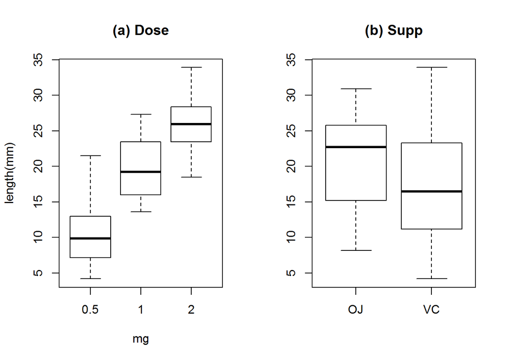

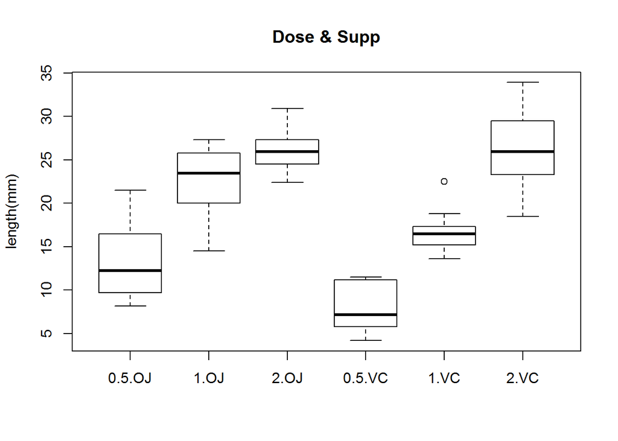

As shown in `Dose`, generally, the tooth length increase as the rise of Vc dose regardless of Supp. And there seems no significant improvement on tooth length when performing different delivery methods (Figure `Supp`). In latter section, we choose to use T-test on these on assumptions due to the small sample size. At first glance of figure `Dose & Supp`, orange Juice seems to perform better at the lower dosages, but has a similar result to Vitamin C at the 2.0mg dosage.

### Hypotheses

We will examine 3 Null Hypotheses in this sections:

1. Different level of Vc dosage have the same effect on tooth length.
2. Orange Juice (OJ) and Vitamin C (VC) have the same effect on tooth length.
3. OJ and VC have the same effect on tooth length when the dosage is the same.

#### Hypothesis 1: Different level of Vc dosage have the same effect on tooth length.

Here we group the data by three levels of dosage and perform T-test between each pair of dosage(0.5~1. 1~2, 0.5~2).

```
##
##  Pairwise comparisons using t tests with non-pooled SD
##
## data:  len and dose
##
##   0.5     1
## 1 2.5e-07 -
## 2 1.3e-13 1.9e-05
##
## P value adjustment method: holm
```

As we can see, the p-value in each pair is much more smaller than 0.05, which indicates that we could reject the Null Hypotheses in 95% confidence interval. In other words, levels of Vc dosage do have significant effect on tooth length in 95% confidence interval.

#### Hypothesis 2: Orange Juice (OJ) and Vitamin C (VC) have the same effect on tooth length.

Now, let’s perform the t-test to the second hypothsis. Here, we group the data by two deliveray methods.

```
##
##  Welch Two Sample t-test
##
## data:  len by supp
## t = 1.9153, df = 55.309, p-value = 0.06063
## alternative hypothesis: true difference in means is not equal to 0
## 95 percent confidence interval:
##  -0.1710156  7.5710156
## sample estimates:
## mean in group OJ mean in group VC
##         20.66333         16.96333
```

The result shows that 95% confidence interval `( -0.1710156, 7.5710156)` contains zero, which suggest that we are not able to reject the Null Hypothesis. Or say that Orange Juice (OJ) and Vitamin C (VC) do have the same effect on tooth length with in 95% confidence interval.

#### Hypothesis 3: OJ and VC have the same effect on tooth length when the dosage is the same.

Hypothesis 3 contains three sub hypotheses, which is OJ and VC have the same effect on tooth length regarding three levels of dosage. Here we check three sub hypotheses using 95% confidence interval.

```
## [1] "0.5" "1"   "2"
## [[1]]
## [1] 1.719057 8.780943
## attr(,"conf.level")
## [1] 0.95
##
## [[2]]
## [1] 2.802148 9.057852
## attr(,"conf.level")
## [1] 0.95
##
## [[3]]
## [1] -3.79807  3.63807
## attr(,"conf.level")
## [1] 0.95
```

As the result shows that we would reject the Null hypothese at `"0.5"` and `"1.0"` dosage levels but fail to reject the Null hypothesis at `"2.0"` levels. The T-tests confirm our initial impression that orange Juice seems to perform better at the lower dosages, but has a similar result to Vitamin C at the 2.0mg dosage.

### Conclusions

In summary, in 95% confidence interval, different level of Vc dosage have effect on tooth length. And in general orange Juice (OJ) and Vitamin C (VC) have the same effect on tooth length. Finally, at `"0.5"` and `"1.0"` dosage levels, OJ and VC show different effects on tooth but simliar effect at `"2.0"`

### Code Chucks

```r
print("Chuck 1")
library(datasets)
data(ToothGrowth)
?ToothGrowth
```

```
## starting httpd help server ... done
```

```r
str(ToothGrowth)
```

```
## [1] "Chuck 1"
## 'data.frame':    60 obs. of  3 variables:
##  $ len : num  4.2 11.5 7.3 5.8 6.4 10 11.2 11.2 5.2 7 ...
##  $ supp: Factor w/ 2 levels "OJ","VC": 2 2 2 2 2 2 2 2 2 2 ...
##  $ dose: num  0.5 0.5 0.5 0.5 0.5 0.5 0.5 0.5 0.5 0.5 ...
```

```r
print("Chuck 2")

# factorising dose
ToothGrowth$dose <- factor(ToothGrowth$dose)

# summarize the data
summary(ToothGrowth)
with(ToothGrowth, table(dose,supp))

# NA data
print("number of NAs"); sum(is.na(ToothGrowth))
```

```
## [1] "Chuck 2"
##       len        supp     dose
##  Min.   : 4.20   OJ:30   0.5:20
##  1st Qu.:13.07   VC:30   1  :20
##  Median :19.25           2  :20
##  Mean   :18.81
##  3rd Qu.:25.27
##  Max.   :33.90
##      supp
## dose  OJ VC
##   0.5 10 10
##   1   10 10
##   2   10 10
## [1] "number of NAs"
## [1] 0
```

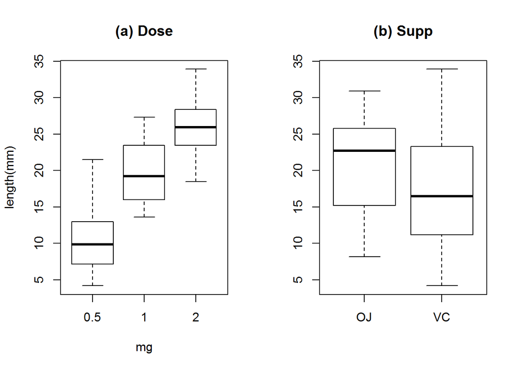

```r
print("Chuck 3")
par(mfrow=c(1,2))
boxplot(len ~ dose, data = ToothGrowth, main="(a) Dose",xlab="mg", ylab="length(mm)")
boxplot(len ~ supp, data = ToothGrowth, main="(b) Supp")
```

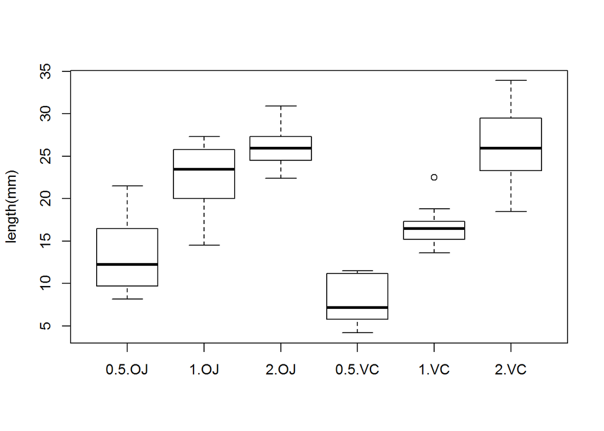

```
## [1] "Chuck 3"
## [1] "Chuck 4"
```

```r
print("Chuck 4")
par(mfrow=c(1,1))
boxplot(len ~ dose*supp, data = ToothGrowth,ylab="length(mm)")
```

```r
print("Chuck 4")
with(ToothGrowth, pairwise.t.test(len,dose, pool.sd=FALSE))
```

```
## [1] "Chuck 4"
##
##  Pairwise comparisons using t tests with non-pooled SD
##
## data:  len and dose
##
##   0.5     1
## 1 2.5e-07 -
## 2 1.3e-13 1.9e-05
##
## P value adjustment method: holm
```

```r
print("Chuck 5")
with(ToothGrowth, t.test(len~supp))
```

```
## [1] "Chuck 5"
##
##  Welch Two Sample t-test
##
## data:  len by supp
## t = 1.9153, df = 55.309, p-value = 0.06063
## alternative hypothesis: true difference in means is not equal to 0
## 95 percent confidence interval:
##  -0.1710156  7.5710156
## sample estimates:
## mean in group OJ mean in group VC
##         20.66333         16.96333
```

```r
print("Chuck 6")
levels <- levels(ToothGrowth$dose);levels

# t-test regarding dose grouped by supp

re <- lapply(1:length(levels), function(i)
    with(ToothGrowth,
         t.test(len[dose==levels[[i]]]~supp[dose==levels[[i]]])
         )
    )

lapply(1:3, function(i) re[[i]]$conf.int)
```

```
## [1] "Chuck 6"
## [1] "0.5" "1"   "2"
## [[1]]
## [1] 1.719057 8.780943
## attr(,"conf.level")
## [1] 0.95
##
## [[2]]
## [1] 2.802148 9.057852
## attr(,"conf.level")
## [1] 0.95
##
## [[3]]
## [1] -3.79807  3.63807
## attr(,"conf.level")
## [1] 0.95
```